# ggplot2 Coding Club ANSWERS

Charlotte Taelman and Heleen Van Ransbeeck

2025-01-13

# Coding club on ggplot2

In this coding club, we are going to uncover all the secrets of ggplot2. If you’ve ever been frustrated with making beautiful visualizations in R, you’re in the right place! We’re here to take you on a journey, from the basics of ggplot2 to advanced techniques, ensuring you learn everything you need to bring your data to life visually.

There are 4 main parts to this coding club * Introduction * Basics & highlights with short exercises * Issues * Two advanced exercises from scratch * Dataset from the London firebrigade on number of rescues of animals over the years * Dataset from 3 species of penguins in the Antarctic region

# The ggplot2 library and its close friends…

```r
library(ggplot2)
library(tidyverse)
library(readxl)
library(writexl)
library(gganimate)
library(ggstream)
library(ggforce)
library(reshape2)
library(wesanderson)
library(showtext)
font_add(family = "ggfont", regular = "./HelloSpark.ttf")
font_add(family = "penguin", regular = "./WinterPenguin.ttf")
showtext_auto()
```

## Practicing Basics & highlights

```r
orange_data = force(Orange) # dataset on growth of orange trees (Tree ID - days old - circumference)
orange_data$Tree = factor(orange_data$Tree, levels = c("1", "2", "3", "4", "5")) # TO DO: stap verduidelijken
```

**1. Basic aesthetics in a simple scatter plot**

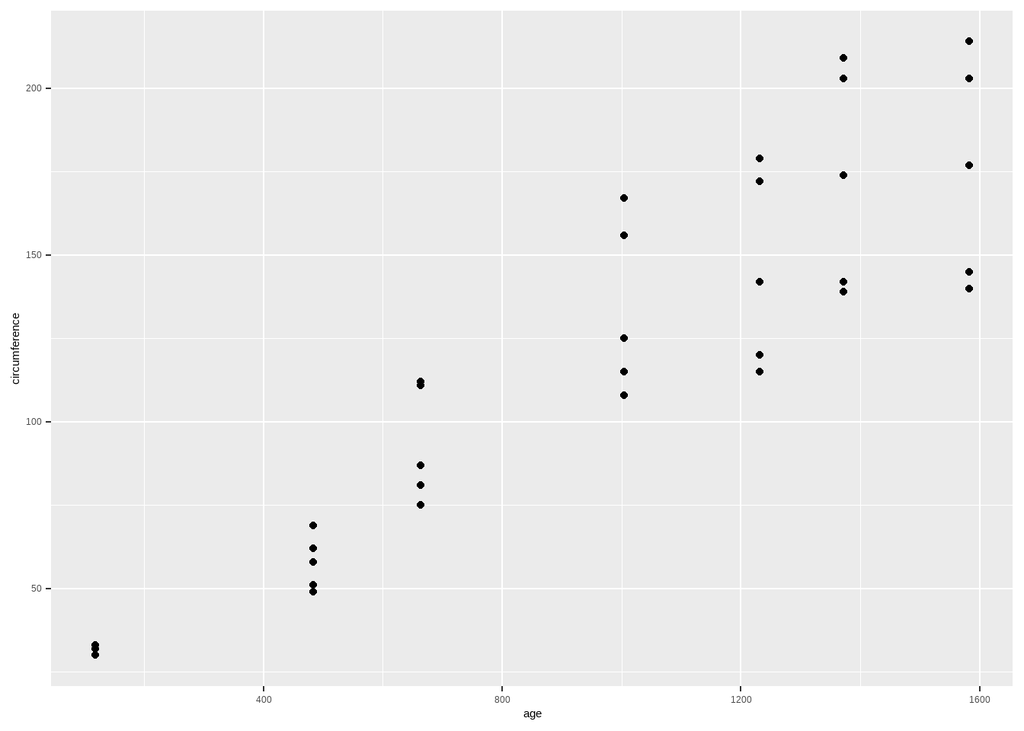

```r
# 1.1 make a basic point graph with age and circumference
ggplot(orange_data, aes(x = age, y = circumference)) +
  geom_point()
```

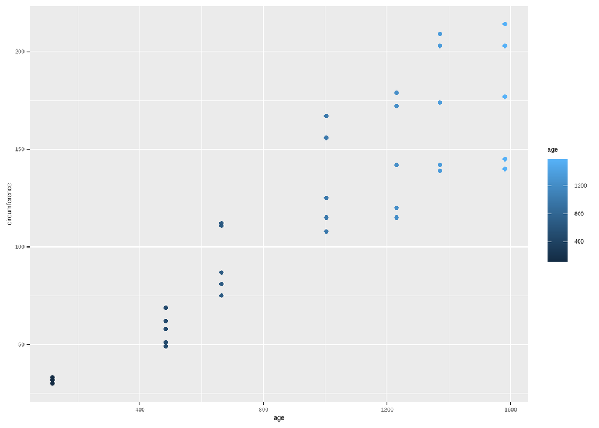

```r
# 1.2 add color to the points according to the age
ggplot(orange_data, aes(x = age, y = circumference, color = age)) + # changing colors according to a variable
  geom_point()                                                      #  -> within aes()
```

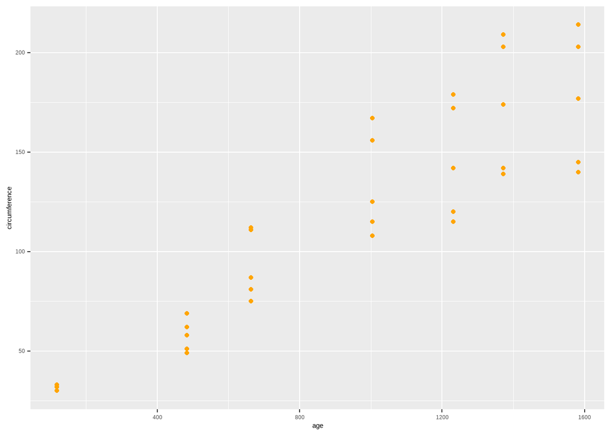

```r
# 1.3 color all the points in orange
ggplot(orange_data, aes(x = age, y = circumference)) +              # all data same color -> outside aes()
  geom_point(color = "orange")
```

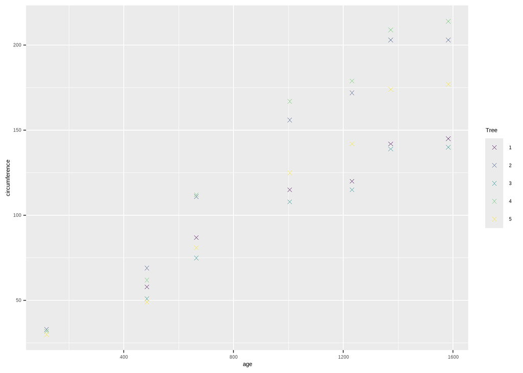

```r
# 1.4 add color to the points according to the tree ID & shape the points like a cross
ggplot(orange_data, aes(x = age, y = circumference, color = Tree)) +
  geom_point(shape=4)
```

**2. Basic geometries & facets**

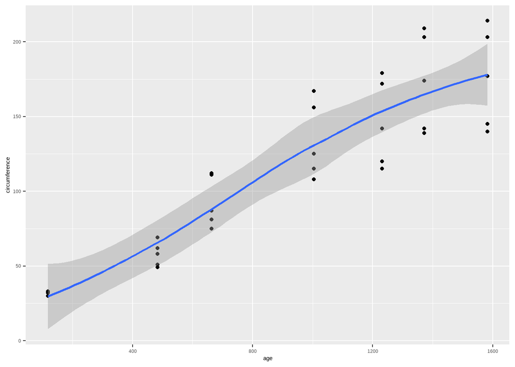

```r
# 2.1 add a smoother to the scatterplot
ggplot(orange_data, aes(x = age, y = circumference)) +
  geom_point() +
  geom_smooth()
```

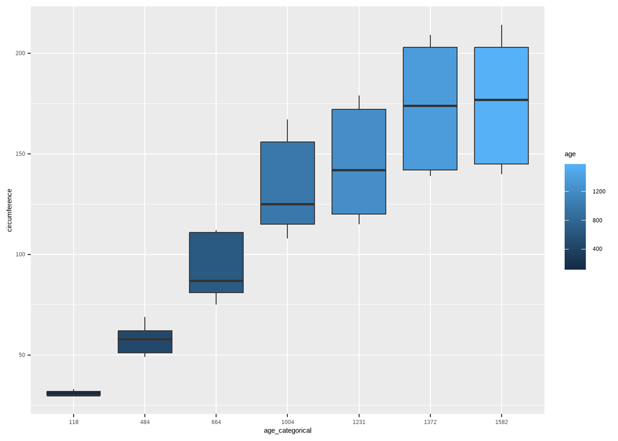

```r
# 2.2 make a boxplot of the lengths of the trees per age, colored
orange_data$age_categorical<-factor(orange_data$age) # transform the ages into a categorical variable
ggplot(orange_data, aes(x = age_categorical, y = circumference, fill = age)) +
  geom_boxplot(aes(group = age_categorical))
```